# ViSiElSe paper: R code walkthrough

Elodie Garnier

2019-10-21

This vignette is a walkthrough the R code used in the paper introducing ViSiElse package (EM Garnier, N Fouret & M Descoins. ViSiElse: An innovative R-package to visualize raw behavioral data over time).

This vignette is organized as the R code in 4 parts:

- 1- ViSiElse setup and data preparation
- 2- Introduction to ViSiElse
- 3- More examples
- 4- Additional informations

### About ViSiElse package

ViSiElse is a graphical tool designed to visualize behavioral observations over time. Based on raw time data extracted from video recorded sessions of experimental observations, ViSiElse grants a global overview of a process by combining the visualization of multiple actions timestamps for all participants in a single graph. Individuals and/or group behavior can easily be assessed. For example, ViSiElse was first developed to visualize the actions performed by caregivers during simulated medical procedures in order to get insights of their behavior. Supplementary features allow users to further inspect their data by adding summary statistics (mean, standard deviation, quantile or statistical test) and/or time constraints to check the accuracy of the realized actions.

A first vignette showing ViSiElse’s step by step process is available here.

## 1- ViSiElse setup and data preparation

### Installation

The first thing to do is simply to install the package and load it.

```r
install.packages("ViSiElse", dependencies = T) # installation
```

```r
library(ViSiElse) # load
```

The installation is done once. All future use of ViSiElse will only require to load the package.

### Data preparation

To explain ViSiElse process, we will use 3 different datasets that are all attached to the package:

- **typDay** dataset: This is the main data that we will use. This dataset shows the actions usually performed during a typical day. The simulated dataset of 100 subjects correspond to the timestamps (in min) of each action of the day, from midnight to midnight. Each value is the time elapse between the beginning of the day (midnight) and the execution of the action.
- **intubation** dataset: Time data from a high-fidelity simulation experiment of a neonatal resuscitation with 37 midwife students. The simulation was video recorded and actions required in the intubation process were tagged. This dataset is the execution time (in seconds) of each action performed by the students.
- **shoppingBehavior** dataset: This dataset shows the buying process of consumers over internet based on a 5-steps model: need recognition, information search, evaluation, purchase decision, and post-purchase behavior. This simulated dataset of 100 subjects correspond to the timestamps (in s) of each action of the model (except for the post-purchase behavior) executed by the subjects.

```r
data("typDay") # load typDay dataset
head(typDay) # print first rows
?typDay # Information about the data

data("intubation") # load intubation dataset
head(intubation) # print first rows
?intubation # Information about the data

data("shoppingBehavior") # load shoppingBehavior dataset
head(shoppingBehavior) # print first rows
?shoppingBehavior # Information about the data
```

## 2- Introduction to ViSiElse

In this section, we will focus on the typical day dataset. All ViSiElse features will be explained through this example.

### The dataset

ViSiElse explores human or animal behavior during a process or a procedure or any observations that can be divided into actions. For example, the typical day tasks can be divided into the following actions: sleep, wake up, take a shower, eat breakfast, drink the first coffee of the day, start and stop working, lunch break, pick up the kids, cook and eat dinner and then finally go to sleep.

If we take a look at the data, we can see that the first column is the subject id and each following column is one action of the typical day. **Each value is the time elapse (in min) between the beginning of the day (midnight) and the execution of the action.**

```r
data("typDay") # load typDay dataset
head(typDay) # print first rows
```

```
##   id start_sleep stop_sleep wake_up shower breakfast start_work
## 1  1           0        366     366    375       389        486
## 2  2           0        391     391    406       426        511
## 3  3           0        329     329    329       334        449
## 4  4           0        335     335    336       342        455
## 5  5           0        437     437    464       496        557
## 6  6           0        353     353    359       370        473
##   start_lunch stop_lunch stop_work pickup_kids start_cook stop_cook
## 1         738        789       985         997       1011      1059
## 2         751        811      1022        1037       1057      1118
## 3         720        757       929         960        965       995
## 4         723        763       938         960        966       999
## 5         774        852      1091        1112       1144      1228
## 6         731        777       964         974        985      1026
##   go_sleep first_coffee
## 1     1326          479
## 2     1351          451
## 3     1289          535
## 4     1295          489
## 5     1397          481
## 6     1313         1068
```

We can see that subject 1 sleeps until 366min of the day (6h06), takes his shower at 6h15 (375min) and eat breakfast at 6h29 (389min). All the data are the timestamps of the actions performed in a day.

### First plot

The dataset is the only required argument to run `visielse()` function. Let’s plot our first ViSiElse graph !

```r
v1 <- visielse(typDay, informer = NULL) # informer = NULL removes the summary statitics that are displayed by default (we will talk about it later).
```

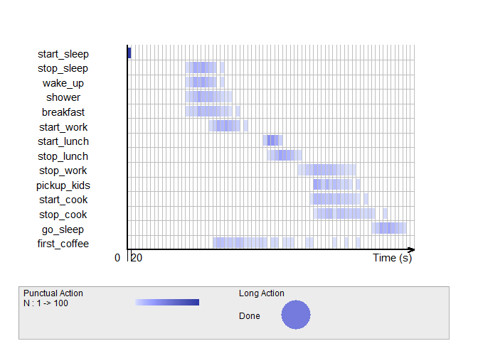

In the legend, we can notice that there are two sections: punctual action and long action. What are punctual and long actions ?

### Punctual and long actions

ViSiElse differentiate two type of actions (punctual and long). A **punctual action** is an action with no duration, or not lasting long enough to be measured regarding the time scale of the studied behavior. A **long action** is an action having duration defined by two punctual actions, one for its beginning, and one for its ending. For example, the action “sleep” is long —it lasts at least a few hours which is substantial in the scale of a day - while the action “wake up” is punctual —it usually only takes seconds or a few minutes and its duration is not relevant in the scale of a day.

For the typical day example, the list of actions can then be transformed to:

- 1- Sleeping — *long*
- 2- Wake up — *punctual*
- 3- Take a shower — *punctual*
- 4- Eat breakfast — *punctual*
- 5- Start working — *punctual*
- 6- Working — *long*
- 7- Stop working — *punctual*
- 8- Lunch break — *long*
- 9- Pick up the kids — *punctual*
- 10- Cook and eat dinner — *long*
- 11- Go to sleep — *punctual*
- 12- First coffee — *punctual*

Now, to visualize both punctual and long actions with ViSiElse, we need a new argument of the `visielse()` function: the **ViSibook** object.

### ViSibook

While the dataset contains the raw time data of the studied behavior, the ViSibook contains its **structure**. Mainly, it is a table consisting of the characteristics of every action.

When running `visielse()` function with only the dataset as argument, the ViSibook is automatically generated and can then be extracted from the visielse object. Then, we can use the `ConvertFromViSibook()` function to transform the ViSibook into a `data.frame` and modify it.

Let’s see what the ViSibook from our first plot looks like !

```r
b1 <- ConvertFromViSibook(v1@book) # Extract the visibook in a data.frame
b1
```

```
##            vars        label typeA showorder  deb  fin
## 1   start_sleep  start_sleep     p         1 <NA> <NA>
## 2   pickup_kids  pickup_kids     p        10 <NA> <NA>
## 3    start_cook   start_cook     p        11 <NA> <NA>
## 4     stop_cook    stop_cook     p        12 <NA> <NA>
## 5      go_sleep     go_sleep     p        13 <NA> <NA>
## 6  first_coffee first_coffee     p        14 <NA> <NA>
## 7    stop_sleep   stop_sleep     p         2 <NA> <NA>
## 8       wake_up      wake_up     p         3 <NA> <NA>
## 9        shower       shower     p         4 <NA> <NA>
## 10    breakfast    breakfast     p         5 <NA> <NA>
## 11   start_work   start_work     p         6 <NA> <NA>
## 12  start_lunch  start_lunch     p         7 <NA> <NA>
## 13   stop_lunch   stop_lunch     p         8 <NA> <NA>
## 14    stop_work    stop_work     p         9 <NA> <NA>
```

The minimum structure of a ViSibook is :

- **vars** : name of the actions. It must be identical to the action names in the dataset
- **label** : label of the actions
- **typeA** : type of the actions. Either “p” for punctual or “l” for long actions.
- **showorder** : action plotted order in the graph. Set to “NA”, the action is not displayed.
- **deb** : for long action only, the name of the punctual action that delimit the beginning of the long one
- **fin** : for long action only, the name of the punctual action that delimit the end of the long one

We can now change the labels and add long actions to our graph !

```r
b1 <- b1[order(as.numeric(b1$showorder)), ] # order the data.frame
# Change the labels of the punctual actions #
b1$label <- c("Sleep", "Stop sleeping", "Wake up", "Take a shower", "Eat breakfast", "Start working", "Start eating lunch", "End of lunch", "Stop working", "Pick up the kids", "Start cooking", "End of dinner", "Go to sleep", "First coffee")
# Define the long actions
b1[15,] <- c("sleep", "Sleeping", "l", 1, "start_sleep", "stop_sleep")
b1[16,] <- c("work", "Working", "l", 5, "start_work", "stop_work")
b1[17,] <- c("lunch", "Lunch break", "l", 6, "start_lunch", "stop_lunch")
b1[18,] <- c("cook", "Cook and eat dinner", "l", 8, "start_cook", "stop_cook")
# Define which actions should be plotted and in which order
b1$showorder <- c(NA, NA, 2, 3, 4, 5, NA, NA, 7, 9, NA, NA, 11, 12, 1, 6, 8, 10)
b1 <- b1[order(as.numeric(b1$showorder)), ] # re-order the ViSibook according to the action order

# The new ViSibook
b1
```

```
##            vars               label typeA showorder         deb        fin
## 15        sleep            Sleeping     l         1 start_sleep stop_sleep
## 8       wake_up             Wake up     p         2        <NA>       <NA>
## 9        shower       Take a shower     p         3        <NA>       <NA>
## 10    breakfast       Eat breakfast     p         4        <NA>       <NA>
## 11   start_work       Start working     p         5        <NA>       <NA>
## 16         work             Working     l         6  start_work  stop_work
## 14    stop_work        Stop working     p         7        <NA>       <NA>
## 17        lunch         Lunch break     l         8 start_lunch stop_lunch
## 2   pickup_kids    Pick up the kids     p         9        <NA>       <NA>
## 18         cook Cook and eat dinner     l        10  start_cook  stop_cook
## 5      go_sleep         Go to sleep     p        11        <NA>       <NA>
## 6  first_coffee        First coffee     p        12        <NA>       <NA>
## 1   start_sleep               Sleep     p        NA        <NA>       <NA>
## 7    stop_sleep       Stop sleeping     p        NA        <NA>       <NA>
## 12  start_lunch  Start eating lunch     p        NA        <NA>       <NA>
## 13   stop_lunch        End of lunch     p        NA        <NA>       <NA>
## 3    start_cook       Start cooking     p        NA        <NA>       <NA>
## 4     stop_cook       End of dinner     p        NA        <NA>       <NA>
```

The long action sleep is defined by the two punctual actions: start_sleep (beginning) and stop_sleep (ending). The punctual actions used to define long actions do not need to be displayed so their order is set to “NA”.

Let’s see the new ViSiElse graph !

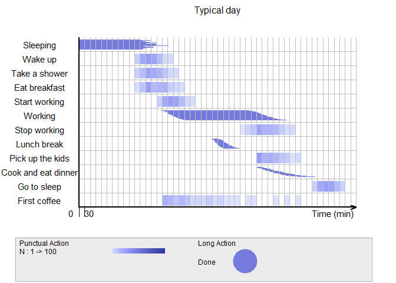

```r
v2 <- visielse(typDay, book = b1, informer = NULL, doplot = F, pixel = 30)
plot(v2, vp0w = 0.7, unit.tps = "min", scal.unit.tps = 30, main = "Typical day")
```

Long actions are displayed by one line per subject with a size proportional to the duration of the action and the lines are sorted by their starting time.

NB1: As long actions are delimited by punctual actions, no additional data are required in the dataset. `visielse()` automatically computes the duration of long actions.

NB2: In the `visielse()` function, *doplot* is set to FALSE as the ViSiElse graph is displayed by the `plot()` function. Using `plot()` allows the access to more formatting options. For example, changing the units of the x-axis (in s by default) or the name of the graph.

### Pixel parameter

You may have notice the use of the *pixel* argument in the `visielse()` function. For punctual actions, the *pixel* parameter represents the **time precision** i.e. the time limit to which one subject is moved from a time interval to another. The default pixel size is set to 20 seconds. It also sets the breaks of the x-axis in the graph. In the `plot()` function, the *pixel* argument is called *scal.unit.tps*. Those two parameters should always be identical.

Data are aggregated into the time intervals. If *pixel* is too small, the plotted information will not be aggregated enough to allow interpretation.

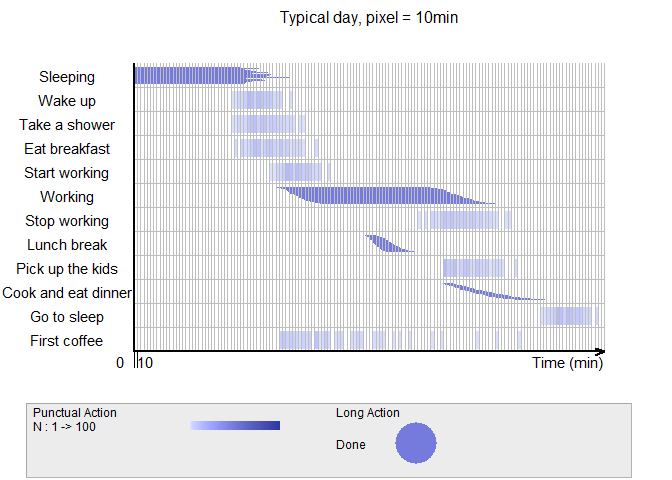

```r
# Small pixel parameter : data are not aggregated enough #
p1 <- 10
v3 <- visielse(typDay, book = b1, informer = NULL, doplot = F, pixel = p1)
plot(v3, vp0w = 0.7, unit.tps = "min", main = "Typical day, pixel = 10min", scal.unit.tps = p1)
```

On the contrary, if *pixel* is too large, the plotted information will be too much aggregated to allow interpretation.

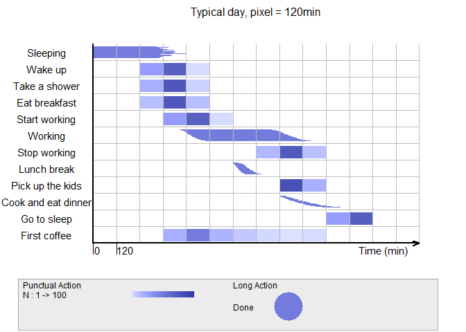

```r
# High pixel parameter : data are too aggregated #
p2 <- 120
v4 <- visielse(typDay, book = b1, informer = NULL, doplot = F, pixel = p2)
plot(v4, vp0w = 0.7, unit.tps = "min", main = "Typical day, pixel = 120min", scal.unit.tps = p2)
```

The pixel parameter must be chosen carefully.

### Groups

ViSiElse enables the differentiation of two subsets of participants through color distinction. Distinguishing experimental groups of participants is useful to identify different patterns of behavior. In the typical day dataset, we created two groups: people who employ a babysitter (in blue) and people who do not (in pink). To display groups with ViSiElse, users simply specify the *group* and the *method* arguments in the `visielse()` function. The first argument is a vector containing the group distribution for each individual. The second argument is the name of the chosen visualization method. ViSiElse provides three methods to plot groups:

- The **“cut”** method where each group is represented one under the other with different colors
- The **“join”** method where groups are spatially mixed but are differentiated by distinct colors
- The **“within”** method where all data are plotted together in blue and one of the groups is plotted again in pink

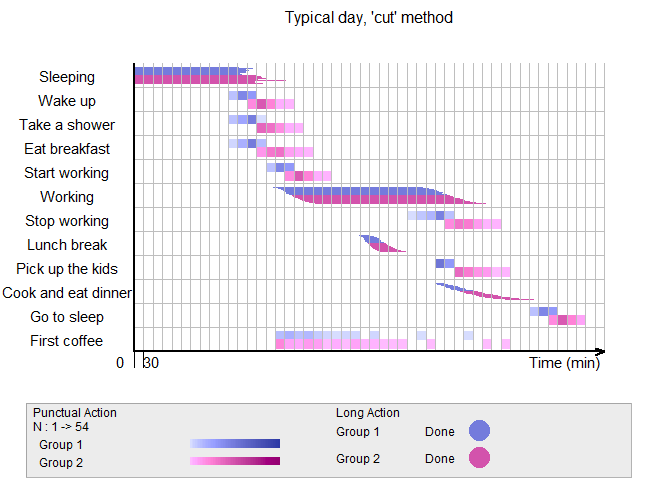

```r
# Group definition
group <- rep(1, 100)
group[typDay$pickup_kids > 1019] <- 2

# Groups plotted with "cut" method : each group is one under the other #
v5 <- visielse(typDay, book = b1, informer = NULL, group = group, method = "cut", tests = F, pixel = 30, doplot = F)
plot(v5, vp0w = 0.7, unit.tps = "min", scal.unit.tps = 30, main = "Typical day, 'cut' method")
```

This representation is useful to compare groups as data are completely dissociated.

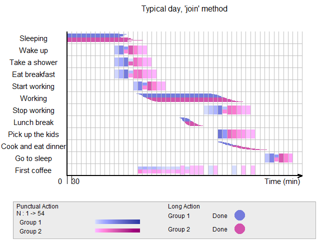

```r
# Groups plotted with "join" method : group spacially mixed #
v6 <- visielse(typDay, book = b1, informer = NULL, group = group, method = "join", tests = F, pixel = 30, doplot = F)
plot(v6, vp0w = 0.7, unit.tps = "min", scal.unit.tps = 30, main = "Typical day, 'join' method")
```

With this method, users can analyze the group distribution among the data.

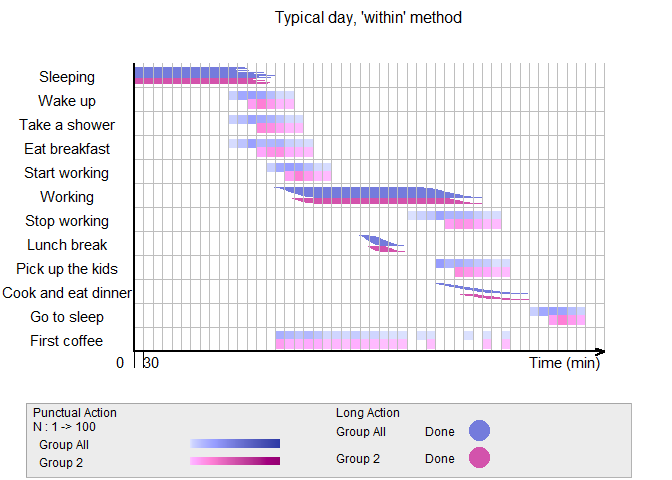

```r
# Groups plotted with "within" method : all data are plotted together in blue
# and the group specified in "grwithin" is plotted again in pink #
v7 <- visielse(typDay, book = b1, informer = NULL, group = group, method = "within", grwithin = "2", tests = F, pixel = 30, doplot = F)
plot(v7, vp0w = 0.7, unit.tps = "min", scal.unit.tps = 30, main = "Typical day, 'within' method")
```

This visualization allows users to examine a specific group behavior against the global population. As the ViSiElse package only allows two colors of distinction, the “within” method is the most suitable option for data containing more than two groups. Users can confront each group, one after the other, to the global population and identify their differences.

### Time constraints: Green and black zones

Green and black zone are here to help visualize **time boundaries** and assess if the actions are done in time. Indeed, some actions can be restricted by time guidelines or external rules. Green zones represent time obligation i.e. when actions should be achieved while black zones set time interdiction i.e. when actions should not occur.

#### Punctual actions

For punctual actions, ViSiElse can display one green zone and two black zones. To create those zones, we only have to add the following new columns in the ViSibook:

- Green Zone: **GZDeb** and **GZFin**
- Black zone 1: **BZBeforeDeb** and **BZBeforeFin**
- Black zone 2: **BZAfterDeb** and **BZAfterFin**

In our typical day example, we can imagine multiple time constraints. For example, the working hours can be delimited. Usually, people should be at work and start working before 10 a.m. (black zone) and they cannot leave work before 4 p.m (black zone). In addition, schools often end at 4 p.m. and close at 5 p.m. so people must pick up their kids during this one-hour interval (black zones before 4p.m. and after 5p.m. and green zone in between).

Let’s add the green and black zones in the ViSibook !

```r
b2 <- b1
b2 <- b2[order(as.numeric(b2$showorder)), ]
# Add definition of the green zones #
b2$GZDeb <- c(rep(NA, 8), 960, rep(NA, 9))
b2$GZFin <- c(rep(NA, 8), 1020, rep(NA, 9))
# Definition of the black zones before the green one #
b2$BZBeforeDeb <- c(rep(NA, 4), 600, NA, 0, NA, 0, rep(NA, 9))
b2$BZBeforeFin <- c(rep(NA, 4), Inf, NA, 960, NA, 960, rep(NA, 9))
# Add definition of the black zones after the green one #
b2$BZAfterDeb <- c(rep(NA, 8), 1020, rep(NA, 9))
b2$BZAfterFin <- c(rep(NA, 8), Inf, rep(NA, 9))
```

Before analyzing the changes made, let’s add the time constraints on long actions.

#### Long actions

No green zone can be plotted for long actions.

```r
# Add definition of the time limit for long action #
b2$BZLong <- c(rep(NA, 7), 30, rep(NA, 10))
b2$BZLtype <- c(rep(NA, 7), "span", rep(NA, 10)) # type should either be "span" (for a duration not to exceed) or "time" (for a deadline not to cross)
b2
```

```
##            vars               label typeA showorder         deb        fin
## 15        sleep            Sleeping     l         1 start_sleep stop_sleep
## 8       wake_up             Wake up     p         2        <NA>       <NA>
## 9        shower       Take a shower     p         3        <NA>       <NA>
## 10    breakfast       Eat breakfast     p         4        <NA>       <NA>
## 11   start_work       Start working     p         5        <NA>       <NA>
## 16         work             Working     l         6  start_work  stop_work
## 14    stop_work        Stop working     p         7        <NA>       <NA>
## 17        lunch         Lunch break     l         8 start_lunch stop_lunch
## 2   pickup_kids    Pick up the kids     p         9        <NA>       <NA>
## 18         cook Cook and eat dinner     l        10  start_cook  stop_cook
## 5      go_sleep         Go to sleep     p        11        <NA>       <NA>
## 6  first_coffee        First coffee     p        12        <NA>       <NA>
## 1   start_sleep               Sleep     p        NA        <NA>       <NA>
## 7    stop_sleep       Stop sleeping     p        NA        <NA>       <NA>
```

[output cut: 42 more lines]

In this new ViSibook, the punctual action “start_work” is associated with a black zone starting at 600min (10 a.m.) and ending at “Inf”. The **“Inf” notation** means that the zone (green or black) should be extended to the end of the studied process. In our case, the end of the day (midnight or 1440min). We can define 3 zones (2 black and 1 green) per punctual action and 1 black zone per long action.

Now, we can see how the time zones are displayed !

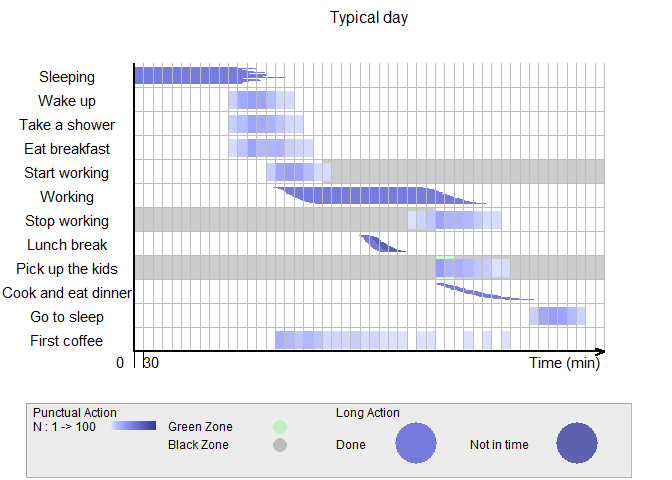

```r
v8 <- visielse(typDay, book = b2, informer = NULL, pixel = 30, doplot = F)
plot(v8, vp0w = 0.7, unit.tps = "min", scal.unit.tps = 30, main = "Typical day")
```

### Statistics

To complete the ViSiElse’s graph and analyze the behavioral data tendency, **summary statistics** can be added with the *informer* argument of the `visielse()` function. Users can choose between plotting the mean and standard deviation or the median with the first and third quartiles.

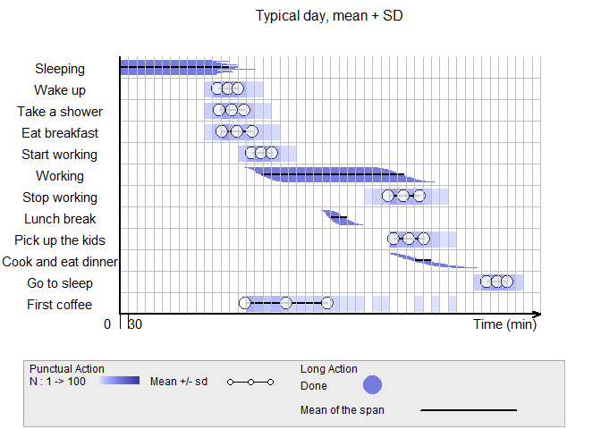

```r
# Mean + standard deviation #
v9 <- visielse(typDay, book = b1, informer = "mean", tests = F, pixel = 30, doplot = F)
plot(v9, vp0w = 0.7, unit.tps = "min", scal.unit.tps = 30, main = "Typical day, mean + SD")
```

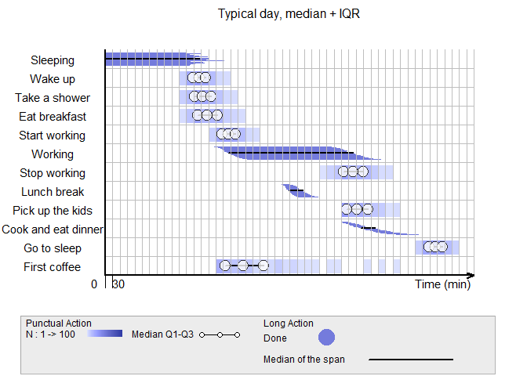

```r
# Median + IQR #
v10 <- visielse(typDay, book = b1, informer = "median", tests = F, pixel = 30, doplot = F)
plot(v10, vp0w = 0.7, unit.tps = "min", scal.unit.tps = 30, main = "Typical day, median + IQR")
```

Moreover, if the data contains groups and summary statistics are defined, ViSiElse computes a statistical test to compare the time data between the two groups. If the *informer* parameter is set to mean and standard deviation, ViSiElse runs a Wilcoxon test; if the *informer* parameter is set to median and quartiles, ViSiElse runs a Mood’s two-sample test. An asterisk appears on the right side of the graph if the statistical test is significant with a 0.01 alpha risk (default value). The alpha risk could be manually set.

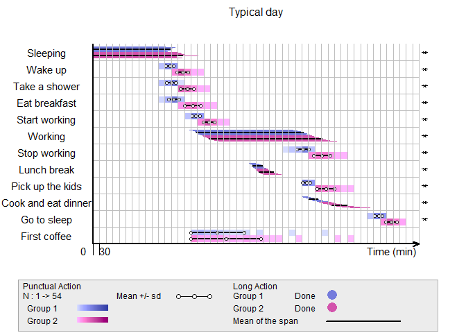

```r
# Statistical test between groups #
v11 <- visielse(typDay, book = b1, informer = "mean", group = group, method = "cut", pixel = 30, doplot = F, tests = TRUE, threshold.test = 0.05)
plot(v11, vp0w = 0.7, unit.tps = "min", scal.unit.tps = 30, main = "Typical day")
```

Here, *informer* is set to mean, so Wilcoxon tests are performed between the groups for each action. The alpha risk is set to 0.05 by the *threshold.test* parameter.

ViSiElse performs statistical tests as an indication of the statistical difference between groups. However, ViSiElse is **not a reporting tool** and only provides the statistical significance of the group comparison. To get complete results and the test details, users should run the tests separately.

## 3- More examples

### Healthcare procedure: intubation

ViSiElse was originally developed to visualize behavioral data extracted from video recorded sessions of **simulated healthcare procedures**. For example, midwife students are trained, through high-fidelity simulation, to the neonatal resuscitation procedure which includes endotracheal intubation (EI). EI is the process of inserting a tube through the mouth and then into the airway in order to ventilate the newborn. By restoring airway patency, EI is a lifesaving procedure and it has to be readily available to all patients whose ventilation is compromised in emergency or anesthesia context. EI consists of six punctual actions completed by two long actions:

- 1- Decision to intubate — *punctual*
- 2- Stop mask ventilation — *punctual*
- 3- Insert the laryngoscope blade in the patient’s mouth — *punctual*
- 4- Insert the endotracheal tube — *punctual*
- 5- Remove the laryngoscope blade out of the patient’s mouth — *punctual*
- 6- Restart to ventilate the patient through the tube — *punctual*
- 7- Duration of the laryngoscope use — *long*
- 8- Total duration of the intubation process — *long*

Let’s create the ViSiElse graph !

```r
data("intubation")
head(intubation)
```

```
##   id deci_intub stop_ventil blade_in insert_tube blade_out restart_ventil
## 1  1         65          76       80          82        93             98
## 2  2        119         150      153         159       163            171
## 3  3        115         144      145         154       175            180
## 4  4        192         233      235         242       255            268
## 5  5        169         187      189         199       206            213
## 6  6        110         157      159         169       191            200
```

The dataset shows the intubation process performed by 37 midwife students during a high-fidelity simulation session.

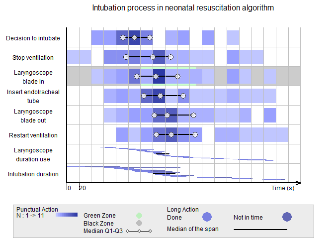

```r
#### Figure 5 in ViSiElse paper ####
v16 <- visielse(intubation, doplot = F)
b3 <- ConvertFromViSibook(v16@book)
b3$label <- c("Decision to intubate", "Stop ventilation", "Laryngoscope\nblade in", "Insert endotracheal\ntube", "Laryngoscope\nblade out", "Restart ventilation")
b3[7,] <- c("dur_laryngoscope", "Laryngoscope\nduration use", "l", "8", "blade_in", "blade_out")
b3[8,] <- c("dur_intub", "Intubation duration", "l", "9", "stop_ventil", "restart_ventil")
b3$GZDeb <- c(NA, NA, 120, NA, NA, NA, NA, NA)
b3$GZDeb <- c(NA, NA, 120, NA, NA, NA, NA, NA)
b3$GZFin <- c(NA, NA, 210, NA, NA, NA, NA, NA)
b3$BZBeforeDeb <- c(NA, NA, 0, NA, NA, NA, NA, NA)
b3$BZBeforeFin <- c(NA, NA, 120, NA, NA, NA, NA, NA)
b3$BZAfterDeb <- c(NA, NA, 210, NA, NA, NA, NA, NA)
b3$BZAfterFin <- c(NA, NA, Inf, NA, NA, NA, NA, NA)
b3$BZLong <- c(rep(NA, 7), 30)
b3$BZLtype <- c(rep(NA, 7), "span")
v17 <- visielse(intubation, book = b3, informer = "median", doplot = F)
plot(v17, scal.unit.tps = 20, rcircle = 8, vp0h = 0.65, vp0w = 0.7, Fontsize.label.Action = 9, Fontsize.label.Time = 9, Fontsize.label.color = 9, main = "Intubation process in neonatal resuscitation algorithm")
```

In the graph, thanks to the long action “intubation duration”, we see that midwives performed the EI heterogeneously during the neonatal resuscitation. Some midwives intubate early in the resuscitation while others only start after 4 min. ViSiElse allows a graphical inspection of the adequacy to the recommendations. For training processes, ViSiElse provides a visual assessment of the performance of caregivers.

NB: We can note the additional formatting options used in the `plot()` function.

### Online Shopping Behavior

Online shopping behavior is a buying process where consumers purchase items over the internet based on a 5-steps model: need recognition, information search, evaluation, purchase decision, and post-purchase behavior. Many factors influencing the buying process have been studied such as nationality, gender, age, education or income.

```r
data("shoppingBehavior")
head(shoppingBehavior)
```

```
##   id need start_search stop_search start_eval stop_eval deci
## 1  1    8           16          38         31        53   61
## 2  2   10           20          50         40        70   80
## 3  3    4            8          18         16        26   30
## 4  4    5           10          22         19        31   36
## 5  5   15           30          75         59       104  119
## 6  6    6           12          30         25        43   49
```

```r
# Define group of participants
group_shop <- c(rep(1, 50), rep(2, 50))
```

The dataset is a simulated dataset for one hundred consumers divided into two groups: 50 women and 50 men.

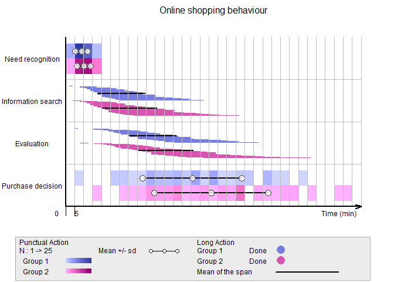

```r
#### Figure 6 in ViSiElse paper ####
v18 <- visielse(shoppingBehavior, doplot = F)
b4 <- ConvertFromViSibook(v18@book)
b4$label <- c("Need recognition", "Start information search", "Stop information search", "Start evaluation", "Stop evaluation", "Purchase decision")
b4$showorder <- c(1, NA, NA, NA, NA, 4)
b4[7,] <- c("search", "Information search", "l", "2", "start_search", "stop_search")
b4[8,] <- c("eval", "Evaluation", "l", "3", "start_eval", "stop_eval")
v19 <- visielse(shoppingBehavior, book = b4, informer = "mean", pixel = 5, group = group_shop, method = "cut", doplot = F)
plot(v19, scal.unit.tps = 5, rcircle = 8, vp0h = 0.6, vp0w = 0.75, Fontsize.label.Action = 9, Fontsize.label.Time = 9, Fontsize.label.color = 9, lwd.grid = 1, lwdline = 2, main = "Online shopping behaviour", unit.tps = "min")
```

With ViSiElse, researchers can visually assess the differences in online shopping behavior between different categories of consumers. ViSiElse graph also displays the summary statistics for each group. This graph is an example of ViSiElse application for online shopping data but ViSiElse representation can be used to visualize any web navigation behavior.

## 4- Additional informations

### Arguments and options management

ViSiElse’s options are accessible through the ViSibook for all the actions characteristics (names, labels, types, order, long action delimitations and green and black zones), through the arguments of the `visielse()` function for all the analysis features (time scale, groups, statistics) and through the arguments of the `plot()` function for all the formatting options.

Formatting options include:

- **scal.unit.tps** : time interval value
- **unit.tps** : time unit (s, min,…)
- **main** : title of the plot
- **size.main** : title size
- **col.main** : title color
- **colgreenzone** : color of the green zone
- **colblackzone** : color of the black zone
- **vp0h** : height of the main plot window (must be <1)
- **vp0w** : width of the main plot window (must be <1)
- **rcircle** : radius of informers circles
- **lwdline** : width of lines linking the 3 informers circles

The complete list is available in the documentation of the `plot-ViSigrid-method` function, [here](https://CRAN.R-project.org/package=ViSiElse/ViSiElse.pdf).

### ViSiElse-like plot with ggplot2 package

In ggplot2 package, the closest graph type to ViSiElse is the `geom_tile()` function (heatmap). Thanks to ggplot2 flexible formatting options, the graph can be design as ViSiElse. However it requires to transform the dataset.

First, the time data should be turned into a frequency table calculating how many subjects performed the action in the time interval. Then, the data should be reshaped to match ggplot2 required data structure. Finally, to match ViSiElse style, 0 values in the dataset should be set to “NA”. With this trick, we can plot “NA” values in white in the formatting options of ggplot2.

Let’s see the modified dataset !

```r
# load the packages
library(ggplot2) # for the heatmap
library(reshape2) # reshape the dataset to adjust its structure

# Create a frequency table with 30min time intervals
typDay2 <-  sapply(typDay[,4:15], function(x){
  table(cut(x, breaks=seq(0, 1440, 30)))
})

# Reshape the dataset to fit ggplot2 data structure
typDay2 <- data.frame(time = factor(seq(0, 1410, 30)), typDay2)
rownames(typDay2) <- 1:nrow(typDay2)
colnames(typDay2) <- c("time", b1$label[c(12, 11, 18, 17, 9, 7, 16, 15, 5, 4, 3, 2)])
typDay2 <- melt(typDay2, id = "time")[, c(2, 1, 3)]

# Set 0 values to "NA"
typDay2$value[typDay2$value == 0] <- NA
head(typDay2)
```

```
##       variable time value
## 1 First coffee    0    NA
## 2 First coffee   30    NA
## 3 First coffee   60    NA
## 4 First coffee   90    NA
## 5 First coffee  120    NA
## 6 First coffee  150    NA
```

The adjusted dataset only contains 3 columns:

- **variable** : label of the actions
- **time** : time interval value
- **value** : number of subject who realized the action in the associated time interval

How does the heatmaps look like ?

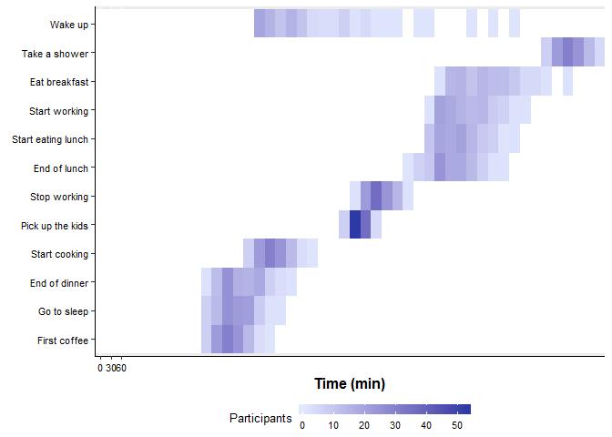

```r
heatmap <- ggplot(data = typDay2, aes(x = time, y = variable, fill = value)) +
  geom_tile() +
  scale_fill_gradient(low = "#E2E8FF", high = "#2D39A5", name = "Participants", na.value = 'white', limit = c(0, 53)) +
  xlab("Time (min)") + ylab(element_blank()) +
  scale_x_discrete(expand = c(0, 0), breaks = seq(0, 60, 30)) +
  theme(axis.line = element_line(colour = "black"),
        axis.title = element_text(size = 12, face = "bold"),
        axis.text = element_text(colour = "black", size = 8)) +
  theme(legend.text = element_text(size = 8),
        legend.title = element_text(size = 10),
        legend.position ="bottom",
        legend.margin = margin(0, 0, 0, 0, unit = "mm"),
        legend.key.width = unit(1, "cm"),
        legend.key.height = unit(3, "mm"))
print(heatmap)
```

The visual output is very close to ViSiElse as the gradient was modified to match ViSiElse colors.

However, we can see that only punctual actions are displayed. Indeed, the main drawback of using `geom_tile()` is that heatmaps do not provide long actions visualization which can be critical. Plotting long actions instead of just the punctual actions (i.e. start and end time) can useful when the duration of actions matter.

In our intubation example, the act of intubation should be as fast as possible considering that the newborn does not receive any oxygen during the procedure. If we only see the start and end time of the intubation, we would not be able to visualize the duration of the intubation. Indeed, for punctual actions, individuals are pulled together so we cannot link a start time to its end time: some might start early and finish early, others might start early but finish late or start late and finish late…

In addition, heatmaps also do not allow groups or time constraints visualization.

## More info

If you have any questions, you can reach us by email at re2simlab@gmail.com

For more documentations, you can see the help in R:

```r
help("visielse")
```

Or you can read the first vignette of the package: ViSiElse Step by Step.